# [CogSci] IntroStat 8 part3

### 8.2 Significance test for the mean (t-tests)

자, 이제 proportion에 대한 유의성 검정을 했으니, 모집단의 평균에 대해서도 유의성 검정을 해야겠지요. 역시나 단측 검정과 양측 검정을 할 수 있습니다.

영가설은 $H_0:\mu = \mu_0$ 일테고, 대립가설은 $H_A:\mu<\mu_0$ 혹은 $\mu>\mu_0$ 혹은 $\mu \neq \mu_0$ 입니다.

모집단의 평균이라고 알려져있는 $\mu_0$에 대해 실제 $\mu$가 더 크거나/작거나/그냥 다를 것을 기대하고 가설 검정을 하되, 우리는 실제 $\mu$를 구할 수 없으니 우리가 추출한 표본의 표본 평균 $\bar{X}$을 사용해서 가설 검정을 하는 겁니다.

다양한 모집단(정규 분포를 따르지 않는 모집단도 있을 수 있습니다)에 대해 유용한 검정 통계량은 다음과 같습니다.

$$T = \frac{\bar{X}-E(\bar{X}|H_0)}{SE(\bar{X}|H_0)} = \frac{\bar{X}-\mu_0}{s/\sqrt{n}}$$

T 라는 검정 통계량을 계산하기 위해 표본 평균($\bar{X}$)이 사용됨을 주의하시기 바랍니다. 그렇기 때문에 T는 표본 분포가 아니라 표집 분포를 갖게 됩니다. 표본의 원소들이 정규 분포에서 나왔다고 할 때, T의 표집 분포는 자유도 n-1의 t-분포입니다. 표본의 크기 n이 커지면 t-분포나 정규 분포나 비슷해지죠. 책의 216페이지 위의 사각형 안에 쓰인 내용을 잘 읽어보시기 바랍니다. 밑에 있는 예제들도 한 번 살펴보시기 바랍니다.

[참고]

한참을 들여다봐도 p.216에 있는 p-value에 대한 설명 중에 $H_A: \mu \neq \mu_0$ 인 경우의 설명을 이해를 못 하겠네요. 저 부분은 그냥 **2$*$P(T $\geq$ |t|)** 라고 이해하시면 될 것 같습니다.

### 8.3 Significant tests and confidence intervals

유의성 검정이나, 신뢰구간 구하기나 R에서는 같은 함수를 씁니다. 이는 두 방법이 같은 검정 통계량을 쓰기 때문입니다.

어떤 표본을 추출했을 때, 이 표본의 모집단은 정규 분포를 따르며, 평균은 $\mu$, 분산은 $\sigma^2$ 라고 해 보겠습니다. 이제 우리는 표본을 이용해 $\mu$에 대한 신뢰구간을 구할 수도 있고, 유의성 검정을 할 수도 있습니다. 둘 중 어떤 방법을 선택하건 간에, T 통계량을 구합니다. T 통계량은 위에도 식이 있으니 다시 쓰지 않겠습니다.

[유의성 검정과 신뢰구간의 관계]

유의도 수준 $\alpha$에 의한 유의성 검정 결과는 표본의 평균인 $\bar{X}$를 중심으로 (1-$\alpha$)$*$100% 의 신뢰 구간이 $\mu_0$를 포함하고 있지 않을 때 영가설을 기각할 겁니다.

유의도 수준을 $\alpha$ = 0.05 라고 삼아보겠습니다. 또한 우리가 추출한 표본의 모집단의 평균이 $\mu$, 표준 편차가 $\sigma$ 라고 가정하겠습니다.

영가설은 $H_0:\mu = \mu_0$ 입니다. 앞에 쓰인 $\mu$는 우리가 구한 표본 평균 $\bar{X}$의 기대값, E[$\bar{X}$] 이고요, 뒤의 $\mu_0$는 $\mu$의 참 값이라고 알려진 어떤 값입니다. 우리는 이 영가설을 기각하거나, 기각하지 못합니다. 그 판단은 이 영가설이 참이라고 가정할 때, 관찰한 T 값에 의해서 내려집니다.

위에 쓴 말을 다시 읽어보겠습니다.

"유의도 수준 $\alpha$에 의한 유의성 검정 결과는 표본의 평균인 **$\bar{X}$를 중심으로 (1-$\alpha$)$*$100% 의 신뢰 구간이 $\mu_0$를 포함하고 있지 않을 때** 영가설을 기각"

$\bar{X}$를 중심으로 (1-$\alpha$)$*$100% 의 신뢰 구간은 어떻게 구하나요? 책 188페이지에 보면, 표본의 크기 n이 크냐 작냐에 따라 다르게 구합니다.

n이 작고, 아까 가정한 대로 모집단의 분포가 Normal($\mu, \sigma^2$) 라고 한다면 (1-$\alpha$)$*$100% 의 신뢰 구간은

[$\bar{X}-t(s/\sqrt{n})$, $\bar{X}+t(s/\sqrt{n})$]라고 구해집니다. $s/\sqrt{n}$는 SE($\bar{X}$) 입니다. t는 역시 책에 쓰여 있는 대로 n-1의 자유도를 갖는 t 분포에서 **P($-t \leq T_{n-1} \leq t) = 1 - \alpha$** 의 관계를 갖는 값입니다.

n이 큰 경우에는 (1-$\alpha$)$*$100% 의 신뢰 구간은

[$\bar{X}-z(s/\sqrt{n})$, $\bar{X}+z(s/\sqrt{n})$]라고 구해집니다. z는 책에 쓰여 있는 대로 **P($-z \leq Z \leq z) = 1 - \alpha$** 의 관계를 갖는 표준 정규 분포의 확률 변수 Z의 값입니다.

t 분포는 통계량 T의 표집 분포입니다. 통계량 T를 계산하는 데 사용 된 표본의 크기 n이 작을 경우에 T는 t 분포를 따릅니다. 만일 n이 충분히 클 경우, t 분포는 정규 분포와 유사해집니다. 아래에 통계량 T의 확률 밀도 함수를 그려보겠습니다. 아래의 확률 밀도 함수는 n이 충분히 크기 때문에 t 분포이지만 정규 분포에 근사합니다.

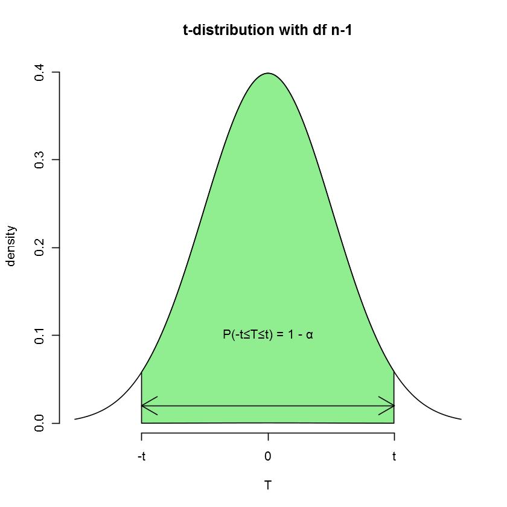

```r
x <- seq(-3, 3, 0.01)
y <- dt(x,length(x)-1)
plot(x, y, type="l", xlab="T", ylab="density", xaxt="n", bty="n",
    main="t-distribution with df n-1")
x.shade <- seq(-1.9639, 1.9639, 0.01)
polygon(c(x.shade, rev(x.shade)), c(dt(x.shade, length(x.shade)-1),
                                    0.001*dt(rev(x.shade), length(x.shade)-1)),
        col="lightgreen")

arrows(-1.9639, 0.02, 1.9639, 0.02, code=3)
axis(1, at=c(-1.9639, 0, 1.9639), labels = c("-t", "0", "t"))
symbol<-"\u2264"
symbol2 <- "\u03B1"
text(0, 0.1, bquote(P*'(-t' * .(symbol) * T * .(symbol) * "t) = 1 - "*.(symbol2)*""))
```

자, 이제 $\alpha$ = 0.05 이기 때문에, t를 구할 수 있습니다. 그러면 T의 값들 중 95%를 포함하는 구간 [-t,t]은 R에서 qt 함수를 구해서 알아볼 수 있겠지요?

```r
# corresponding t's
qt(c(0.025, 0.975), df=length(x)-1)
```

1. -1.96392562204273

2. 1.96392562204273

```r
# z-scores for the same condition
qnorm(c(0.025, 0.975), mean=0, sd=1)
```

1. -1.95996398454005

2. 1.95996398454005

우리가 원하는 구간은 [-1.9639, 1.9639] 라고 구해졌습니다. 바로 밑에 정규 분포의 경우 같은 구간 [-z, z]를 구했는데, 이 역시 [-1.96, 1.96] 으로 t 분포가 n이 충분히 큰 경우 정규 분포에 근사한다는 것을 확인할 수 있습니다. 소수점 세 자리 까지만 표현하겠습니다.

T 통계량의 정의를 통해, 아래의 등식이 성립하게 됩니다.

$$P(-t \leq \frac{\bar{X}-\mu_0}{s/\sqrt{n}} \leq t) = P(\bar{X}-t(s/\sqrt{n}) \leq \mu_0 \leq \bar{X}+t(s/\sqrt{n})) = 1-\alpha$$

위의 등식은 이제 이렇게 고쳐 쓸 수 있습니다.

$$P(-1.96 \leq \frac{\bar{X}-\mu_0}{s/\sqrt{n}} \leq 1.96) = P(\bar{X}-1.96(s/\sqrt{n}) \leq \mu_0 \leq \bar{X}+1.96(s/\sqrt{n})) = 0.95$$

만약 우리가 관찰한 T 값이 1.96 보다 크면 어떻게 될까요? 그럼 해당 T 값을 구하는 데 사용되는 $\bar{X}$를 통해 계산 되는 신뢰 구간이 $\mu_0$를 포함하지 않을 것입니다. 아래의 등식에서처럼, 신뢰 구간의 최소 값이 $\mu_0$보다 크기 때문입니다.

$$\frac{\bar{X}-\mu_0}{s/\sqrt{n}}>1.96 ~ = ~\bar{X}-1.96(s/\sqrt{n}) > \mu_0$$

만약 관찰한 T 값이 -1.96보다 작으면 반대로 신뢰 구간의 최대 값이 $\mu_0$보다 작기 때문에 $\mu_0$를 포함하지 않을 것입니다.

95%의 신뢰 구간이 $\mu_0$를 포함하지 않는다, 다시 말해 모든 가능한 신뢰 구간들 중 95% 미만이 $\mu_0$를 포함하는 것은, 관찰 된 표본 평균 $\bar{X}$를 통해 계산 된 T 값이 우리가 설정한 신뢰수준(($1-\alpha$)$*$100%)이 결정하는 특정 T값 구간 내에 있지 않다는 이야기입니다.

이 확률은 어떻게 구하나요? 다시 말해 $P(T \geq 1.96 ~or~ T \leq -1.96)$은 어떻게 구할 수 있나요? T 가 가질 수 있는 값들의 확률의 총합은 1입니다. 그러므로 당연히 아래와 같이 구합니다.

$$P(T \geq 1.96 ~or~ T \leq -1.96) ~=~ 1-P(-1.96 \leq T \leq 1.96) ~=~ 1-0.95 = 0.05$$

$P(T \geq 1.96 ~or~ T \leq -1.96)$이 양측 검정에서 T의 p-value 라는 것을 이해하시겠지요? 결국 유의 수준 $\alpha$가 0.05 일 때, p-value가 0.05 이하인 T 통계량을 관찰하게 되면 우리의 영가설 [*표본 평균의 기대 값($\mu$)이 $\mu_0$*] 을 기각한다는 뜻입니다.

예를 들어, T 가 2가 나왔다고 해 보지요. 양측 검정에서 이 T의 p-value는 얼마일까요?

```r
# The probability of observing the T-value of 2
1- pt(2, df=length(x)-1)
```

0.0229752713306451

```r
# The p-value of T = 2 for the two-sided test
2*(1-pt(2,df=length(x)-1))
```

0.0459505426612903

0.046이 나옵니다. 그러니까 이 T 값은 곧 유의 수준이 0.05 일 경우에, 95%보다 적은 비율의 신뢰 구간들이 영가설이 주장하는 $\mu_0$를 포함하고 있기 때문에 영가설을 기각해야 하는 T 값입니다. 저 위에 있는 T 분포의 확률 밀도 함수에서 초록색 영역을 제외한 흰 색 영역(=기각역)에 T 값이 포함되는 경우는 아래의 $\bar{X}$의 확률 밀도 함수에서 우리가 구한 표본 평균 $\bar{x}$가 역시나 분홍색 영역을 제외한 흰 색 영역에 들어 있는 경우와 동일합니다.

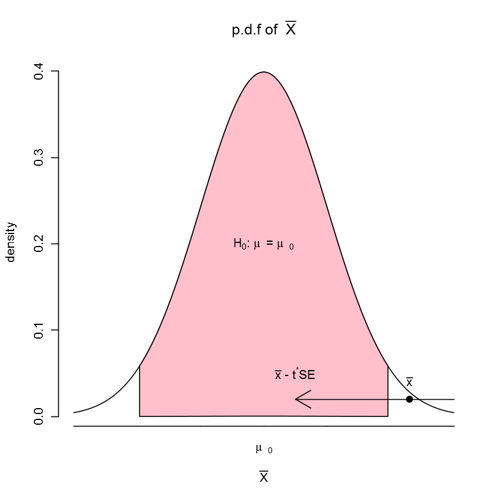

```r
x <- seq(-3, 3, 0.01)
y <- dnorm(x,0,1)
plot(x, y, type="l", xlab=expression(bar(X)), ylab="density", xaxt="n",
    bty="n", main=expression(paste("p.d.f of  ", bar(X))))
x.shade <- seq(-1.96, 1.96, 0.01)
polygon(c(x.shade, rev(x.shade)), c(dnorm(x.shade), 0.001*dnorm(rev(x.shade))), col="pink")
arrows(0.5, 0.02, 3, 0.02, code=1)
axis(1, at=c(-3,-2,-1,0,1,2,3),
     labels = c("", "", "", expression(mu[0]), "", "", ""), tck=0)
text(0, 0.2, expression(paste(H[0], ": ", mu, "= ", mu[0])))
text(0.5, 0.05, expression(paste(bar(x), " - ", "t"^"*", "SE")))
points(2.3, 0.02, pch=19)
text(2.3, 0.04, expression(bar(x)))
```

여기서도 흰 색 영역들이 기각역입니다. $\bar{x}$가 기각역에서 관찰이 되니, 유의 수준에 따라 계산되는 $t^{*}$와, 그 $t^{*}$로 계산되는 신뢰 구간은 영가설에 의해 주장되는 $\mu = \mu_0$를 포함하지 않지요. 그러면 (1-$\alpha$)$*$100%의 신뢰 구간이 $\mu_0$를 포함하지 않게 되므로, 영가설을 기각해야 할 겁니다.

8.3 에서 마지막으로 하는 이야기는, 신뢰 구간이 p-value 보다 좀 더 선호되는 데, 그 이유는 유의성 검정이 실패할 확률, 다시 말해 유의 수준보다 작은 p-value는 실제 모집단의 평균에 대한 이야기는 해 줄 수 없고, 단순히 영가설을 기각해야 하는 지 아닌 지만 알려주기 때문입니다. 제일 처음에 영가설의 기각이 대립 가설의 증명이 아니라고 했던 것을 기억해 보시기 바랍니다. 반면 신뢰 구간은 직접적으로 실제 모집단의 평균이 어느 정도 값 근처에 위치할지 알려주기 때문에 더 선호하게 되는 것입니다.

책의 예와 비슷하게 영가설이 평균 0.49를 주장한다고 해 보겠습니다. 참 값이 0.5 라고 해 보겠습니다. p-value는 n이 커짐에 따라 임의로 변경이 가능합니다.

```r
# for small n, n=200
sample <- c(rep(1, 100), rep(0, 100))
t.test(sample, mu=0.49, alt="two.sided")
```

```
	One Sample t-test

data:  sample
t = 0.28213, df = 199, p-value = 0.7781
alternative hypothesis: true mean is not equal to 0.49
95 percent confidence interval:
 0.4301059 0.5698941
sample estimates:
mean of x
      0.5
```

n = 200인 경우에 양측 검정에서 p-value가 0.7781 입니다. 이래서야 영가설을 기각하지 못하겠지요. 신뢰 구간도 넓어서 모집단의 진짜 평균이 0.5인지 명확하게 알 수가 없습니다. 이제 n을 키워보겠습니다.

```r
# for large n, n=2,000,000
sample2 <- c(rep(1,1000000), rep(0, 1000000))
t.test(sample2, mu = 0.49, alt="two.sided")
```

```
	One Sample t-test

data:  sample2
t = 28.284, df = 2e+06, p-value < 2.2e-16
alternative hypothesis: true mean is not equal to 0.49
95 percent confidence interval:
 0.499307 0.500693
sample estimates:
mean of x
      0.5
```

이제 n = 2,000,000인 경우입니다. 양측 검정에서 p-value가 2.2e-16 (R 에서는 이런 숫자가 나오면 0이라고 이해하시면 됩니다) 가 나왔습니다. 이는 곧 영가설을 기각해야 하는 확률이 1이라는 뜻이지요. 또한 신뢰 구간이 매우 조밀해져서 이제 0.49는 신뢰 구간에 포함되지 않고, 대신 진짜 모집단의 평균이 0.5에 매우 가까운 것을 확인할 수 있습니다.

$$P(\bar{X}-1.96(s/\sqrt{n}) \leq \mu_0 \leq \bar{X}+1.96(s/\sqrt{n})) = 0.95$$

그러나 p-value, 신뢰 구간 모두 유용한 통계적 추론 방법들입니다.